# CMPINF 2130 Summer 2021 - Week 05

Dr. Joseph P. Yurko

6/14/2021

## Load packages

```r
library(tidyverse)
```

## Review bar chart

Use the `mpg` data set for counts instead of `iris`.

```r
mpg %>% glimpse()
```

```
## Rows: 234
## Columns: 11
## $ manufacturer <chr> "audi", "audi", "audi", "audi", "audi", "audi", "audi", "~
## $ model        <chr> "a4", "a4", "a4", "a4", "a4", "a4", "a4", "a4 quattro", "~
## $ displ        <dbl> 1.8, 1.8, 2.0, 2.0, 2.8, 2.8, 3.1, 1.8, 1.8, 2.0, 2.0, 2.~
## $ year         <int> 1999, 1999, 2008, 2008, 1999, 1999, 2008, 1999, 1999, 200~
## $ cyl          <int> 4, 4, 4, 4, 6, 6, 6, 4, 4, 4, 4, 6, 6, 6, 6, 6, 6, 8, 8, ~
## $ trans        <chr> "auto(l5)", "manual(m5)", "manual(m6)", "auto(av)", "auto~
## $ drv          <chr> "f", "f", "f", "f", "f", "f", "f", "4", "4", "4", "4", "4~
## $ cty          <int> 18, 21, 20, 21, 16, 18, 18, 18, 16, 20, 19, 15, 17, 17, 1~
## $ hwy          <int> 29, 29, 31, 30, 26, 26, 27, 26, 25, 28, 27, 25, 25, 25, 2~
## $ fl           <chr> "p", "p", "p", "p", "p", "p", "p", "p", "p", "p", "p", "p~
## $ class        <chr> "compact", "compact", "compact", "compact", "compact", "c~
```

The number of observations for each unique value of `class` in `mpg`.

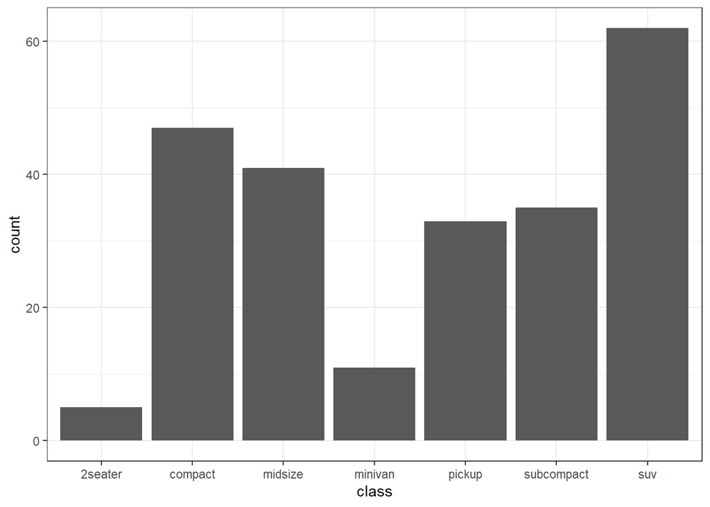

```r
mpg %>%
  ggplot(mapping = aes(x = class)) +
  geom_bar() +
  theme_bw()
```

Reorder the x-axis.

The character gets converted to a factor variable behind the scenes. A factor is R’s terminology for a categorical.

```r
mpg %>%
  mutate(class = as.factor(class)) %>%
  select(class)
```

```
## # A tibble: 234 x 1
##    class
##    <fct>
##  1 compact
##  2 compact
##  3 compact
##  4 compact
##  5 compact
##  6 compact
##  7 compact
##  8 compact
##  9 compact
## 10 compact
## # ... with 224 more rows
```

Let’s print the factor to the screen.

```r
mpg %>%
  mutate(class = as.factor(class)) %>%
  select(class) %>%
  pull()
```

```
##   [1] compact    compact    compact    compact    compact    compact
##   [7] compact    compact    compact    compact    compact    compact
##  [13] compact    compact    compact    midsize    midsize    midsize
##  [19] suv        suv        suv        suv        suv        2seater
##  [25] 2seater    2seater    2seater    2seater    suv        suv
##  [31] suv        suv        midsize    midsize    midsize    midsize
##  [37] midsize    minivan    minivan    minivan    minivan    minivan
##  [43] minivan    minivan    minivan    minivan    minivan    minivan
##  [49] pickup     pickup     pickup     pickup     pickup     pickup
##  [55] pickup     pickup     pickup     suv        suv        suv
##  [61] suv        suv        suv        suv        pickup     pickup
##  [67] pickup     pickup     pickup     pickup     pickup     pickup
##  [73] pickup     pickup     suv        suv        suv        suv
##  [79] suv        suv        suv        suv        suv        pickup
##  [85] pickup     pickup     pickup     pickup     pickup     pickup
```

[output cut: 25 more lines]

We can use the `levels()` function to extract the finite set of levels or values the factor can take.

```r
mpg %>%
  mutate(class = as.factor(class)) %>%
  select(class) %>%
  pull() %>%
  levels()
```

```
## [1] "2seater"    "compact"    "midsize"    "minivan"    "pickup"
## [6] "subcompact" "suv"
```

We can manually override the order by specyfing the levels.

```r
mpg %>%
  mutate(class = factor(class, levels = c("suv", "subcompact", "pickup",
                                          "2seater",
                                          "minivan", "midsize", 'compact'))) %>%
  select(class) %>%
  pull() %>%
  levels()
```

```
## [1] "suv"        "subcompact" "pickup"     "2seater"    "minivan"
## [6] "midsize"    "compact"
```

The level order dictates the order of the x-axis in the bar chart.

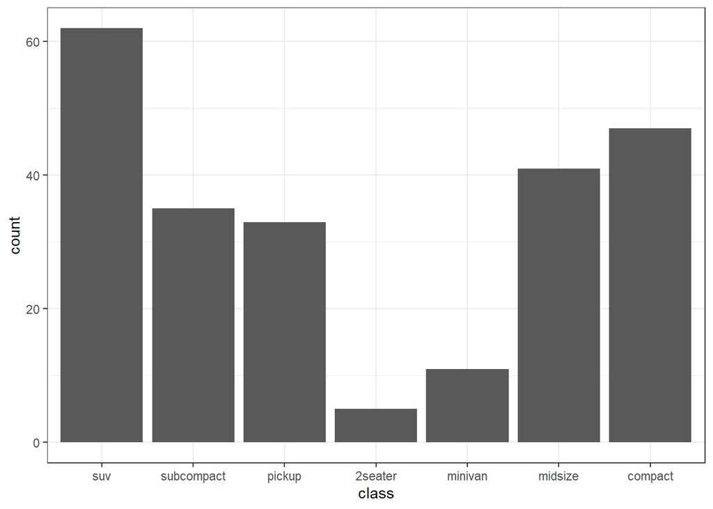

```r
mpg %>%
  mutate(class = factor(class, levels = c("suv", "subcompact", "pickup",
                                          "2seater",
                                          "minivan", "midsize", 'compact'))) %>%
  ggplot(mapping = aes(x = class)) +
  geom_bar() +
  theme_bw()
```

What if we want to order by count?

Let’s first check by chaining `count()` and `arrange()`.

```r
mpg %>%
  count(class) %>%
  arrange(n)
```

```
## # A tibble: 7 x 2
##   class          n
##   <chr>      <int>
## 1 2seater        5
## 2 minivan       11
## 3 pickup        33
## 4 subcompact    35
## 5 midsize       41
## 6 compact       47
## 7 suv           62
```

Extract out the `class` column from the summarized data set.

```r
class_ascend_order <- mpg %>%
  count(class) %>%
  arrange(n) %>%
  select(class) %>%
  pull()
```

Now we can order the x-axis based on ascending counts.

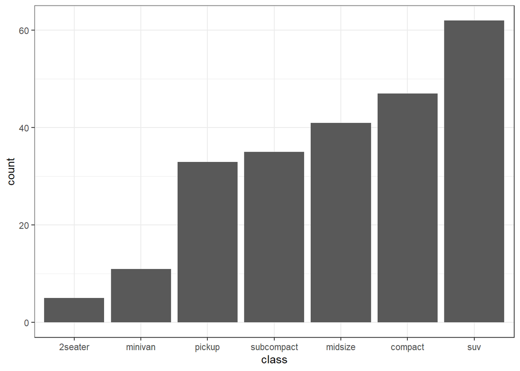

```r
mpg %>%
  mutate(class = factor(class, levels = class_ascend_order)) %>%
  ggplot(mapping = aes(x = class)) +
  geom_bar() +
  theme_bw()
```

[forcats](https://forcats.tidyverse.org/) streamlines manipulating categorical variables.

```r
mpg %>%
  mutate(class = forcats::fct_infreq(class)) %>%
  select(class) %>%
  pull() %>%
  levels()
```

```
## [1] "suv"        "compact"    "midsize"    "subcompact" "pickup"
## [6] "minivan"    "2seater"
```

Visualize the counts as a bar chart using the forcats ordering.

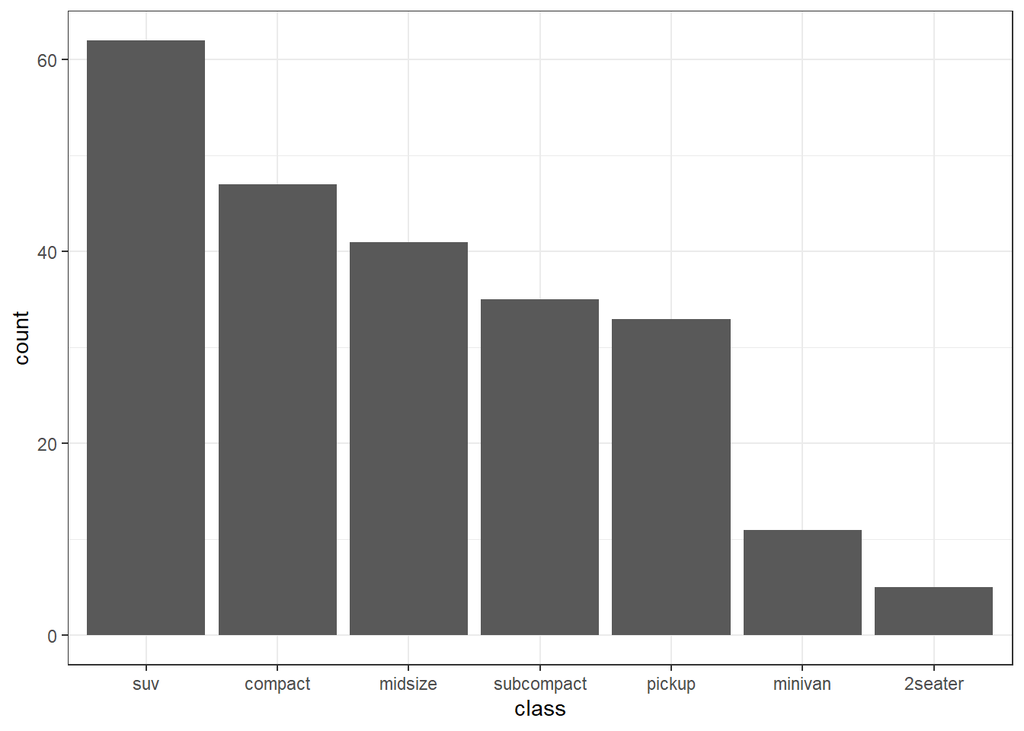

```r
mpg %>%
  mutate(class = forcats::fct_infreq(class)) %>%
  ggplot(mapping = aes(x = class)) +
  geom_bar() +
  theme_bw()
```

We can reverse the order showing lowest count to highest. Manually call the reverse order function.

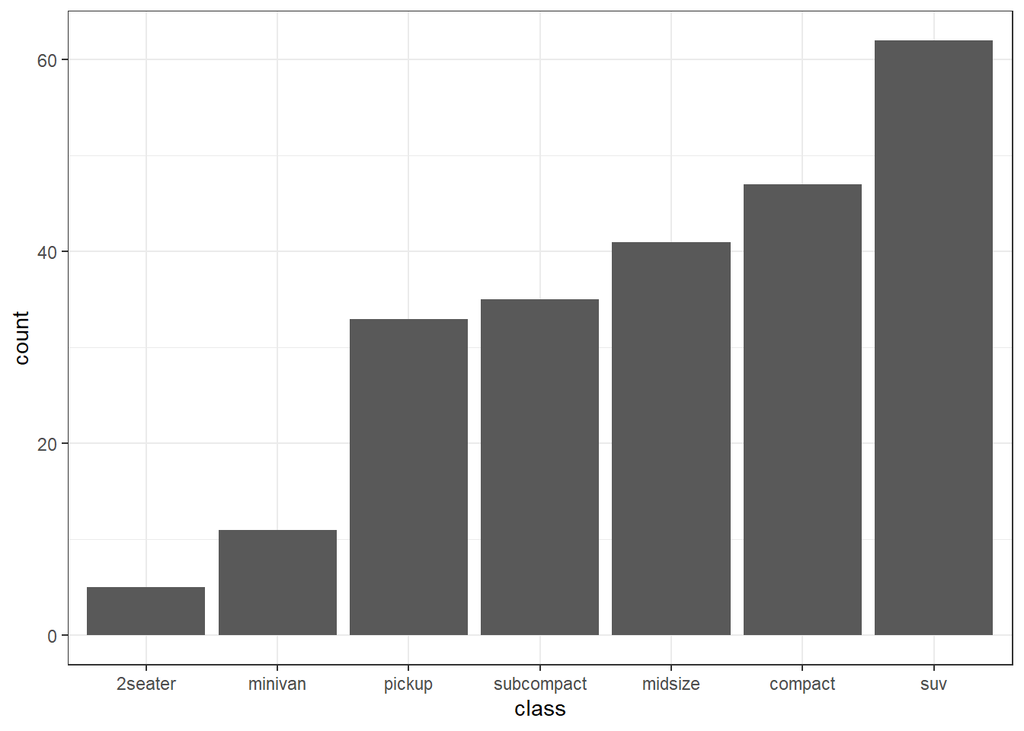

```r
mpg %>%
  mutate(class = forcats::fct_infreq(class)) %>%
  mutate(class = forcats::fct_rev(class)) %>%
  ggplot(mapping = aes(x = class)) +
  geom_bar() +
  theme_bw()
```

We can also include the count as text.

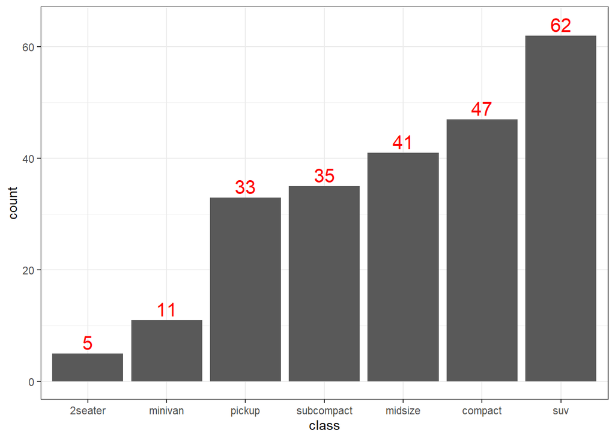

```r
mpg %>%
  mutate(class = forcats::fct_infreq(class)) %>%
  mutate(class = forcats::fct_rev(class)) %>%
  ggplot(mapping = aes(x = class)) +
  geom_bar() +
  geom_text(stat = 'count',
            mapping = aes(label = stat(count)),
            color = 'red', nudge_y = 2, size = 5.5) +
  theme_bw()
```

### Lumping

forcats has a dedicated set of functions to perform the “lumping” for us.

```r
mpg %>%
  mutate(class = forcats::fct_lump_min(class, 15)) %>%
  count(class)
```

```
## # A tibble: 6 x 2
##   class          n
##   <fct>      <int>
## 1 compact       47
## 2 midsize       41
## 3 pickup        33
## 4 subcompact    35
## 5 suv           62
## 6 Other         16
```

Let’s now look at a bar chart which includes the lumped “Other” variable.

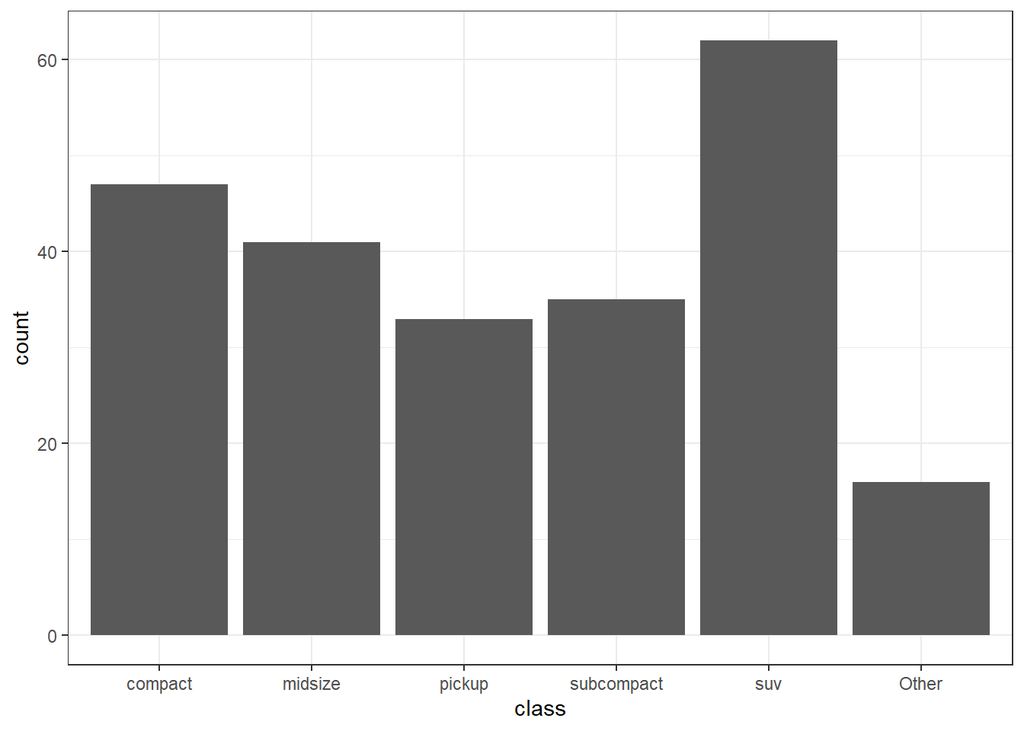

```r
mpg %>%
  mutate(class = forcats::fct_lump_min(class, 15)) %>%
  ggplot(mapping = aes(x = class)) +
  geom_bar() +
  theme_bw()
```

Let’s reorder by the count.

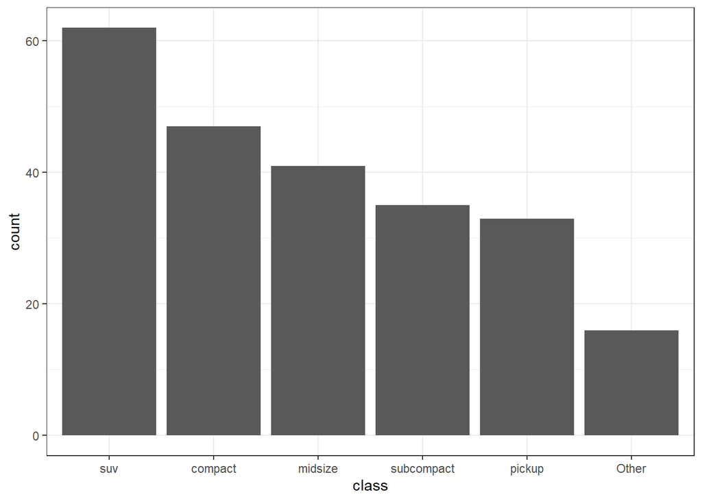

```r
mpg %>%
  mutate(class = forcats::fct_lump_min(class, 15)) %>%
  mutate(class = forcats::fct_infreq(class)) %>%
  ggplot(mapping = aes(x = class)) +
  geom_bar() +
  theme_bw()
```

We can rename the “Other” level.

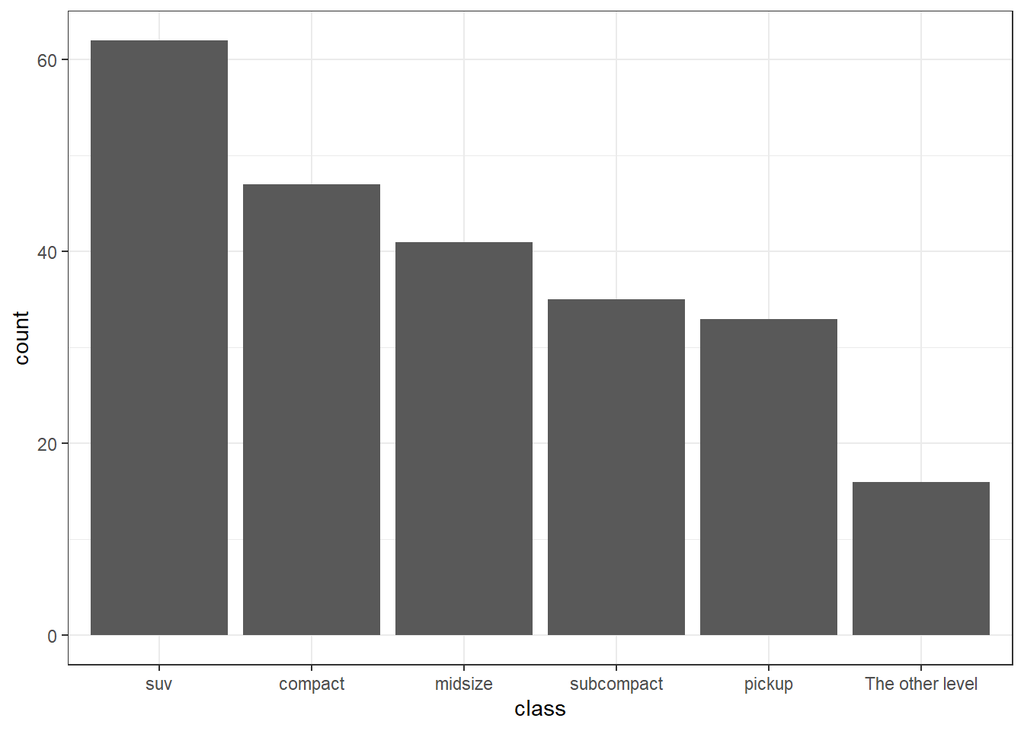

```r
mpg %>%
  mutate(class = forcats::fct_lump_min(class, 15, other_level = "The other level")) %>%
  mutate(class = forcats::fct_infreq(class)) %>%
  ggplot(mapping = aes(x = class)) +
  geom_bar() +
  theme_bw()
```

Lumping based on less than 15 observations does not scale to larger or smaller data sets. Instead we should consider the **proportion**.

Let’s manually calculate the proportion of each value.

```r
mpg %>%
  count(class) %>%
  mutate(prop_value = n / sum(n)) %>%
  arrange( desc(prop_value) )
```

```
## # A tibble: 7 x 3
##   class          n prop_value
##   <chr>      <int>      <dbl>
## 1 suv           62     0.265
## 2 compact       47     0.201
## 3 midsize       41     0.175
## 4 subcompact    35     0.150
## 5 pickup        33     0.141
## 6 minivan       11     0.0470
## 7 2seater        5     0.0214
```

Check the proportions.

```r
62 / nrow(mpg)
```

```
## [1] 0.2649573
```

Let’s now visualize the levels as proportions instead of counts. Let’s first use `geom_col()`.

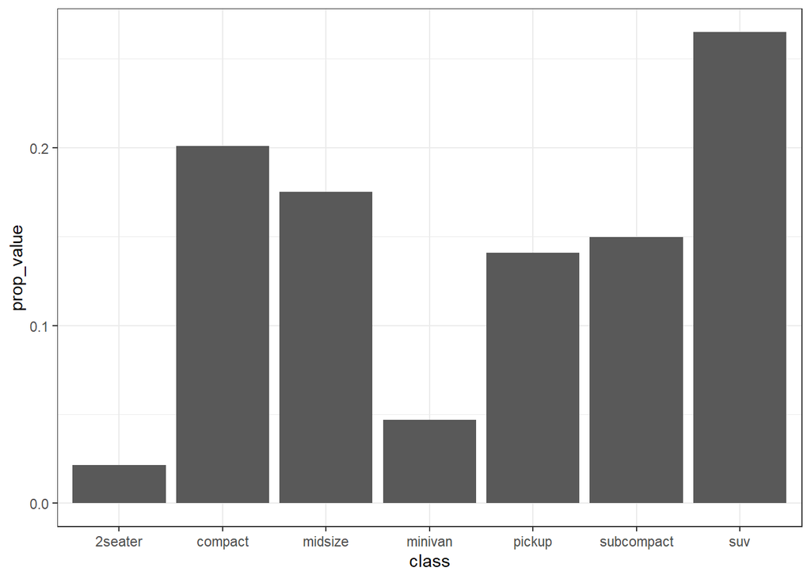

```r
mpg %>%
  count(class) %>%
  mutate(prop_value = n / sum(n)) %>%
  arrange( desc(prop_value) ) %>%
  ggplot(mapping = aes(x = class, y = prop_value)) +
  geom_col() +
  theme_bw()
```

Reorder the levels.

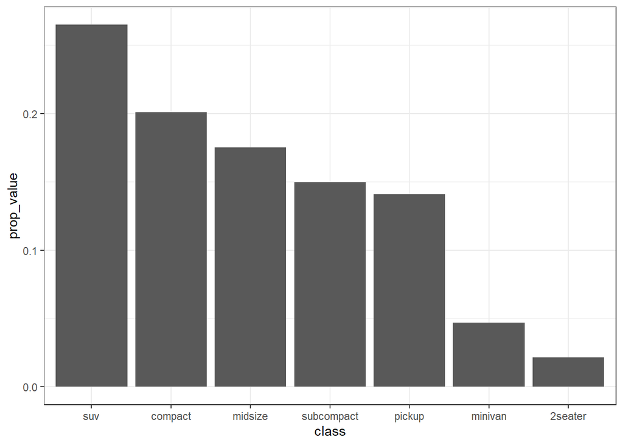

```r
mpg %>%
  count(class) %>%
  mutate(prop_value = n / sum(n)) %>%
  arrange( desc(prop_value) ) %>%
  mutate(class = forcats::fct_inorder(class)) %>%
  ggplot(mapping = aes(x = class, y = prop_value)) +
  geom_col() +
  theme_bw()
```

If you want the percent, just multiply by 100.

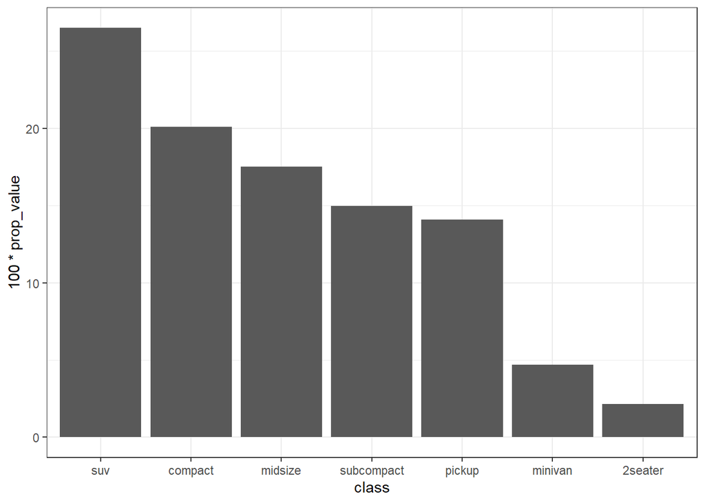

```r
mpg %>%
  count(class) %>%
  mutate(prop_value = n / sum(n)) %>%
  arrange( desc(prop_value) ) %>%
  mutate(class = forcats::fct_inorder(class)) %>%
  ggplot(mapping = aes(x = class, y = 100 * prop_value)) +
  geom_col() +
  theme_bw()
```

If we multiply outside of ggplot.

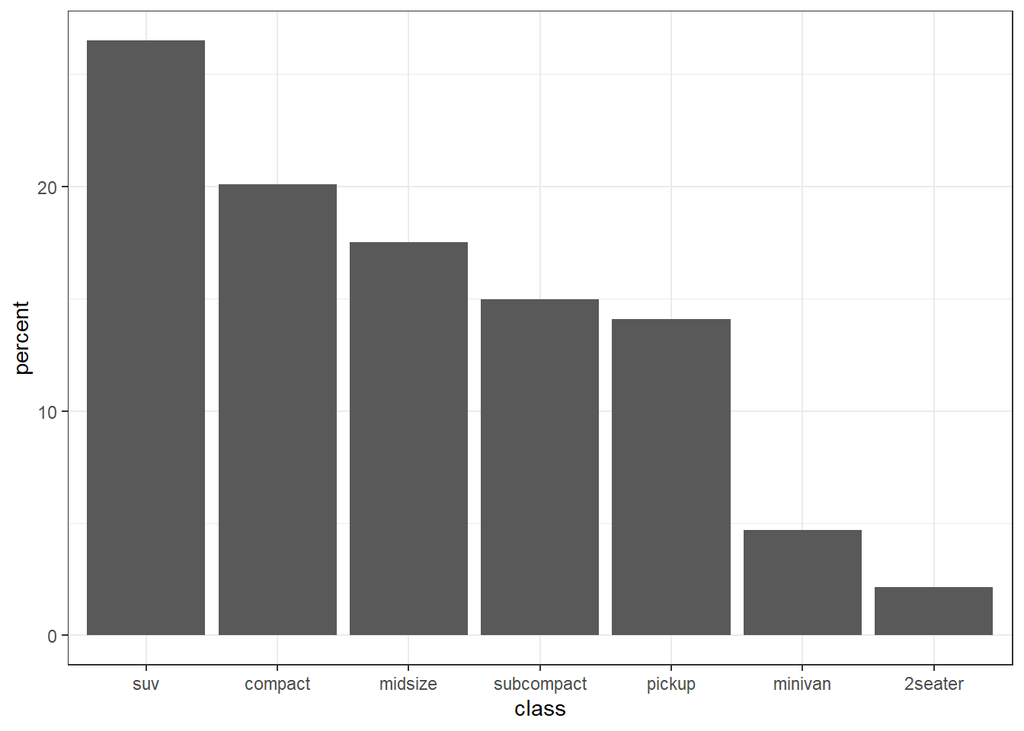

```r
mpg %>%
  count(class) %>%
  mutate(prop_value = n / sum(n)) %>%
  arrange( desc(prop_value) ) %>%
  mutate(class = forcats::fct_inorder(class)) %>%
  mutate(prop_value = 100 * prop_value) %>%
  ggplot(mapping = aes(x = class, y = prop_value)) +
  geom_col() +
  # manually override the axis labels
  labs(y = "percent") +
  theme_bw()
```

Ideally, we want ggplot2 to show us the proportions from the original or raw data set. We have to make use of the `stat()` function again.

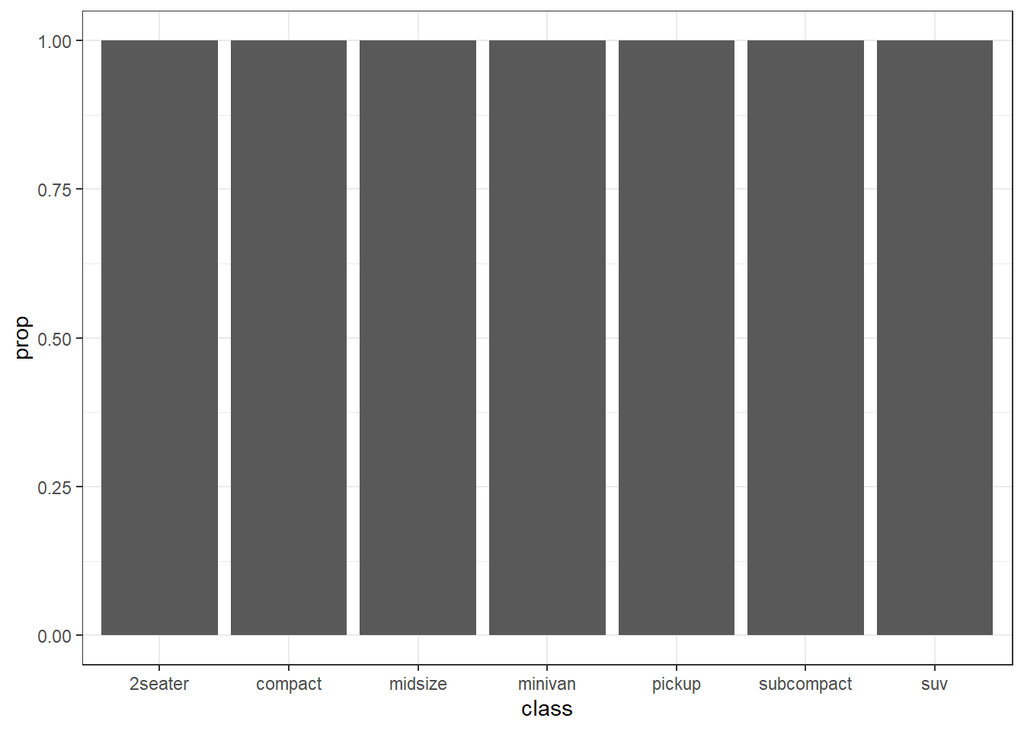

```r
mpg %>%
  ggplot(mapping = aes(x = class)) +
  geom_bar(mapping = aes(y = stat(prop))) +
  theme_bw()
```

To override the grouping and visualize the proportion relative to the WHOLE data set we must specify `group = 1` in aes().

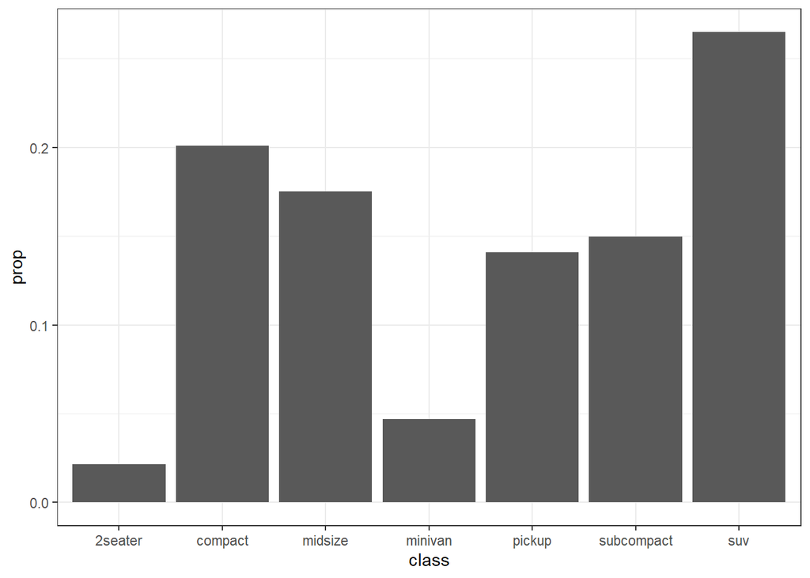

```r
mpg %>%
  ggplot(mapping = aes(x = class)) +
  geom_bar(mapping = aes(y = stat(prop),
                         group = 1)) +
  theme_bw()
```

We can reorder the level as needed.

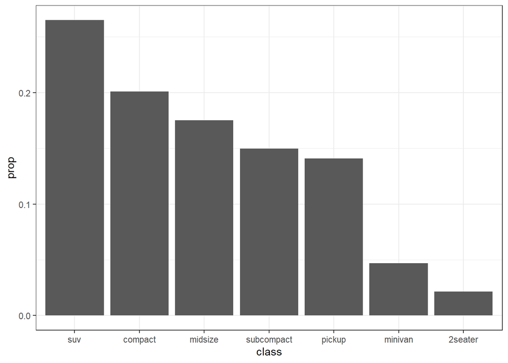

```r
mpg %>%
  mutate(class = forcats::fct_infreq(class)) %>%
  ggplot(mapping = aes(x = class)) +
  geom_bar(mapping = aes(y = stat(prop),
                         group = 1)) +
  theme_bw()
```

We can also display the proportion as text.

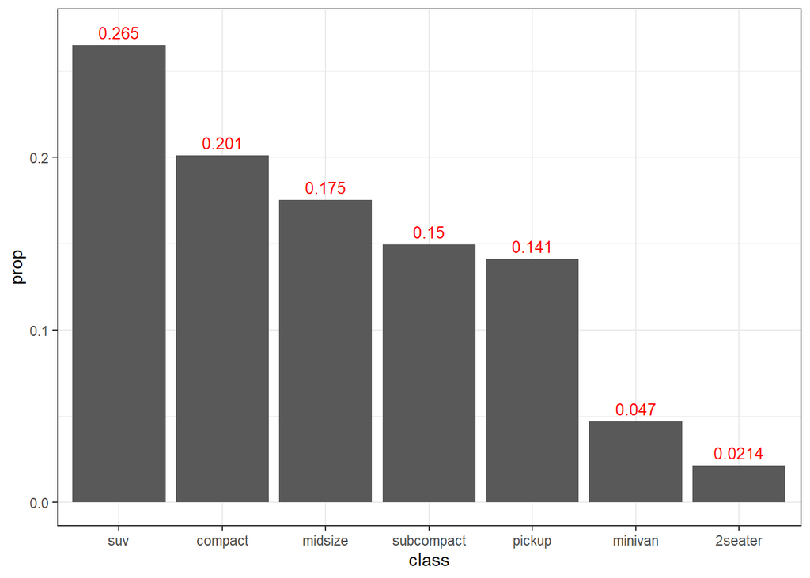

```r
mpg %>%
  mutate(class = forcats::fct_infreq(class)) %>%
  ggplot(mapping = aes(x = class)) +
  geom_bar(mapping = aes(y = stat(prop),
                         group = 1)) +
  geom_text(stat = 'count',
            mapping = aes(y = after_stat( count / sum(count)),
                          label = after_stat( signif(count / sum(count), 3) )),
            color = 'red', nudge_y = 0.0075, size = 3.5) +
  theme_bw()
```

Lump all values or levels of `class` together if they occur less than 5% of the time. Or, the level **proportion** is less than 0.05.

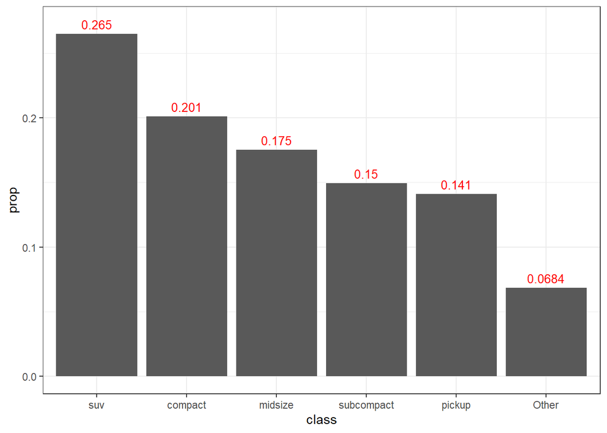

```r
mpg %>%
  mutate(class = forcats::fct_lump_prop(class, 0.05)) %>%
  mutate(class = forcats::fct_infreq(class)) %>%
  ggplot(mapping = aes(x = class)) +
  geom_bar(mapping = aes(y = stat(prop),
                         group = 1)) +
  geom_text(stat = 'count',
            mapping = aes(y = after_stat( count / sum(count)),
                          label = after_stat( signif(count / sum(count), 3) )),
            color = 'red', nudge_y = 0.0075, size = 3.5) +
  theme_bw()
```

## Combinations

`drv` tells us if the vehicle is 4wheel, front, or rear wheel drive.

```r
mpg %>% count(drv)
```

```
## # A tibble: 3 x 2
##   drv       n
##   <chr> <int>
## 1 4       103
## 2 f       106
## 3 r        25
```

Let’s look at the counts of the combinations of `drv` and `class`.

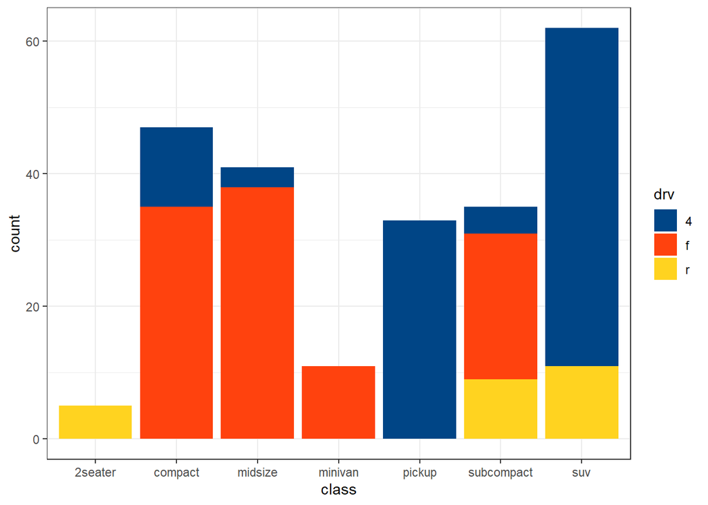

```r
mpg %>%
  ggplot(mapping = aes(x = class)) +
  geom_bar(mapping = aes(fill = drv)) +
  ggthemes::scale_fill_calc() +
  theme_bw()
```

When we want to know the proportion **within** the x-aesthetic group we only need to specify the position as `'fill'` to know the proportion.

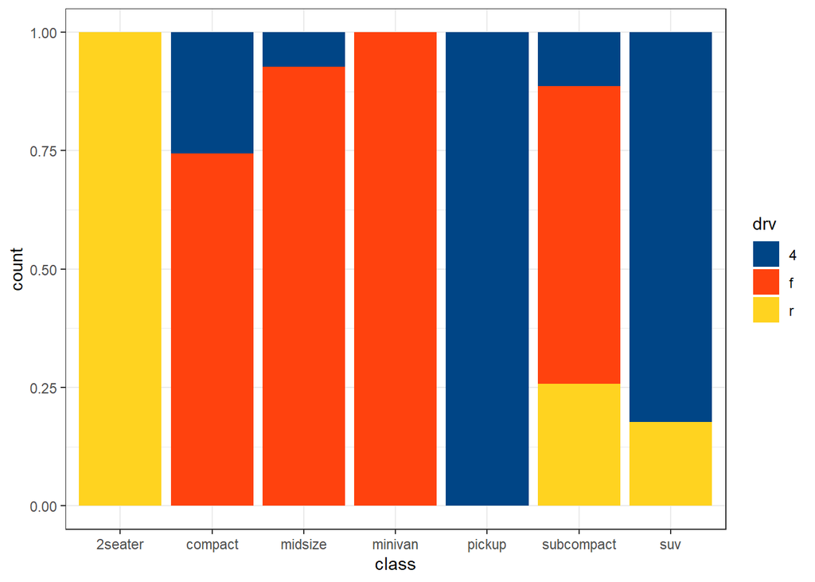

```r
mpg %>%
  ggplot(mapping = aes(x = class)) +
  geom_bar(mapping = aes(fill = drv),
           position = 'fill') +
  ggthemes::scale_fill_calc() +
  theme_bw()
```

Use `labs()` to change the y-axis label.

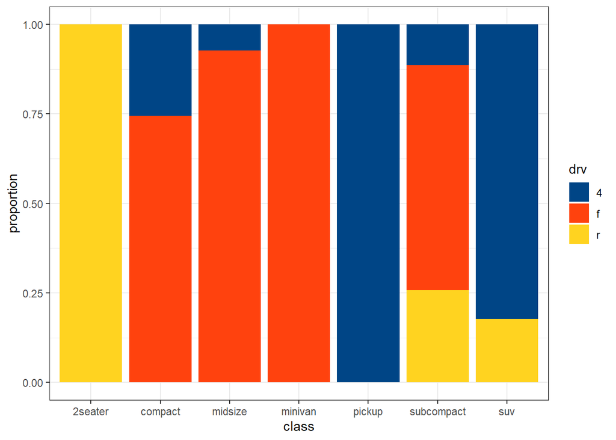

```r
mpg %>%
  ggplot(mapping = aes(x = class)) +
  geom_bar(mapping = aes(fill = drv),
           position = 'fill') +
  ggthemes::scale_fill_calc() +
  labs(y = 'proportion') +
  theme_bw()
```

Add a title.

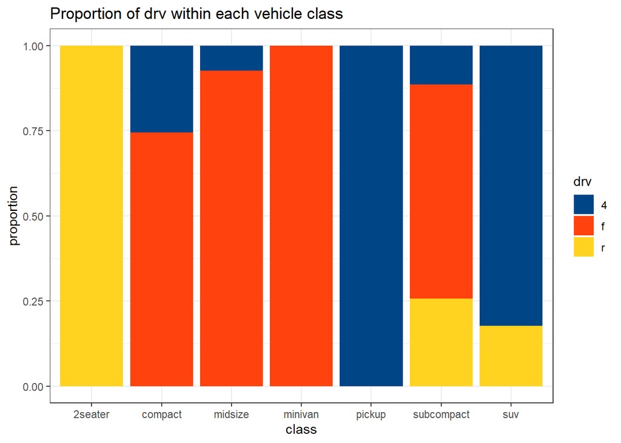

```r
mpg %>%
  ggplot(mapping = aes(x = class)) +
  geom_bar(mapping = aes(fill = drv),
           position = 'fill') +
  ggthemes::scale_fill_calc() +
  labs(y = 'proportion',
       title = 'Proportion of drv within each vehicle class') +
  theme_bw()
```

Instead, we might be interested in the proportio of the combination directly.

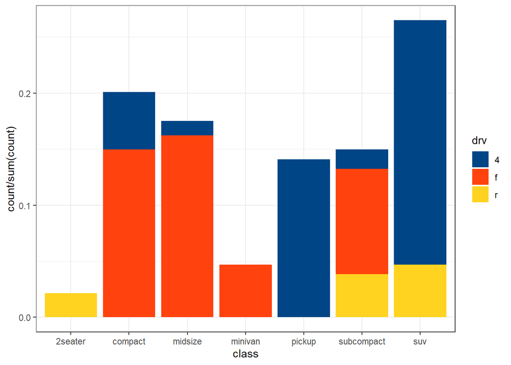

```r
mpg %>%
  ggplot(mapping = aes(x = class)) +
  geom_bar(mapping = aes(fill = drv,
                         y = after_stat( count / sum(count) ))) +
  ggthemes::scale_fill_calc() +
  theme_bw()
```

Lastly, we can ‘dodge’ to help see the individual combination proportions.

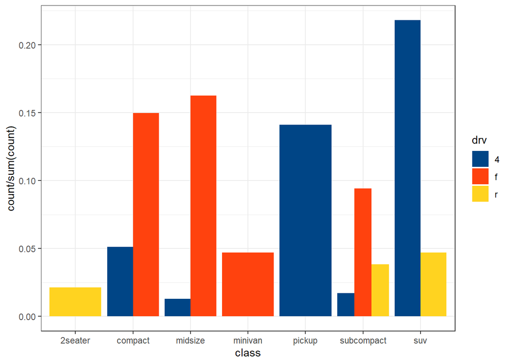

```r
mpg %>%
  ggplot(mapping = aes(x = class)) +
  geom_bar(mapping = aes(fill = drv,
                         y = after_stat( count / sum(count) )),
           position = 'dodge') +
  ggthemes::scale_fill_calc() +
  theme_bw()
```

We can check the counts/proportions.

```r
mpg %>%
  count(class, drv) %>%
  mutate(prop_value = n / sum(n))
```

```
## # A tibble: 12 x 4
##    class      drv       n prop_value
##    <chr>      <chr> <int>      <dbl>
##  1 2seater    r         5     0.0214
##  2 compact    4        12     0.0513
##  3 compact    f        35     0.150
##  4 midsize    4         3     0.0128
##  5 midsize    f        38     0.162
##  6 minivan    f        11     0.0470
##  7 pickup     4        33     0.141
##  8 subcompact 4         4     0.0171
##  9 subcompact f        22     0.0940
## 10 subcompact r         9     0.0385
## 11 suv        4        51     0.218
## 12 suv        r        11     0.0470
```

## Continuous variables

We will start with synthetic data. We will generate 5000 random draws or samples from a **standard normal distribution**.

**standard** refers to the fact that the **mean** is equal to 0 and the standard deviation is equal 1.

**z-score** has a mean zero and variance one.

When generating random numbers it’s always import to set the random seed.

```r
set.seed(2130)
x <- rnorm(n = 5000)

x %>% length()
```

```
## [1] 5000
```

Check the summary statistics with `summary()`.

```r
x %>% summary()
```

```
##      Min.   1st Qu.    Median      Mean   3rd Qu.      Max.
## -3.440045 -0.645436  0.025635  0.009555  0.656646  4.044719
```

Let’s put `x` inside a data.frame, or really a tibble.

```r
xdf <- tibble::tibble(x = x)

xdf %>% glimpse()
```

```
## Rows: 5,000
## Columns: 1
## $ x <dbl> 0.48985558, 0.27478193, 0.05470678, -0.17662471, -0.92091499, -0.240~
```

As a continuous variable, `x`, does not have a finite set of values. There’s essentially an infinite set of possible values.

```r
xdf %>%
  summarise(n_distinct(x))
```

```
## # A tibble: 1 x 1
##   `n_distinct(x)`
##             <int>
## 1            5000
```

We cannot simply use a bar chart for a continuous number!

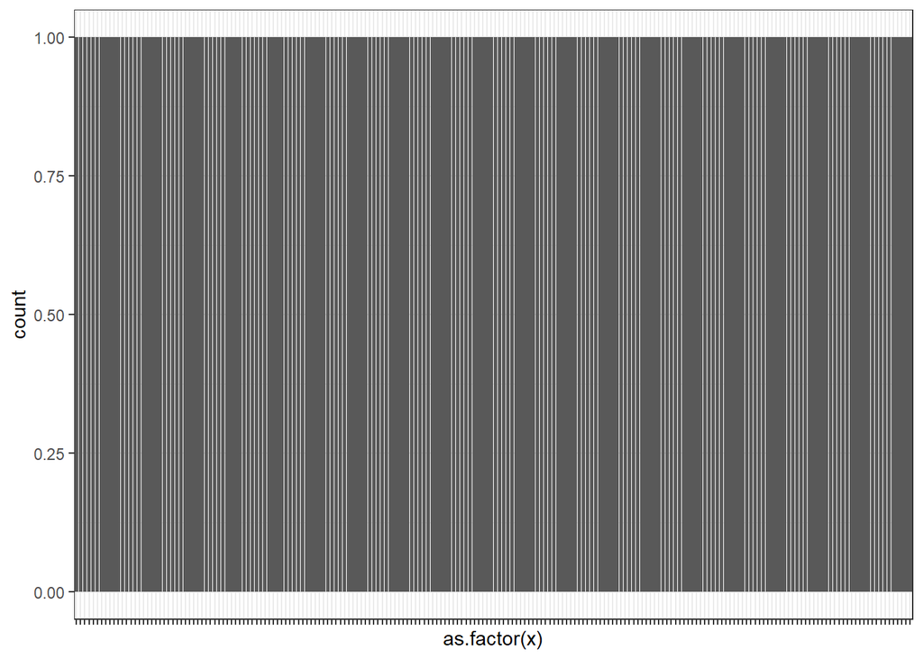

```r
xdf %>%
  slice(1:200) %>%
  ggplot(mapping = aes(x = as.factor(x))) +
  geom_bar() +
  theme_bw() +
  theme(axis.text.x = element_blank())
```

Let’s print the first 25 values to the screen.

```r
xdf %>%
  count(x) %>%
  arrange(x) %>%
  head(25)
```

```
## # A tibble: 25 x 2
##        x     n
##    <dbl> <int>
##  1 -3.44     1
##  2 -3.44     1
##  3 -3.32     1
##  4 -3.15     1
##  5 -3.14     1
##  6 -3.12     1
##  7 -3.06     1
##  8 -3.03     1
##  9 -2.98     1
## 10 -2.95     1
## # ... with 15 more rows
```

We can **bin** similar observations together. A histogram is a “bar chart” for continuous variables. A histogram is made by:

- “breaking” or dividing the *range* into smaller intervals or **bins**
- count the number of observations in each bin
- display a bar chart to show the counts in each bin

Let’s see what happens if we use the quantiles to divide the space.

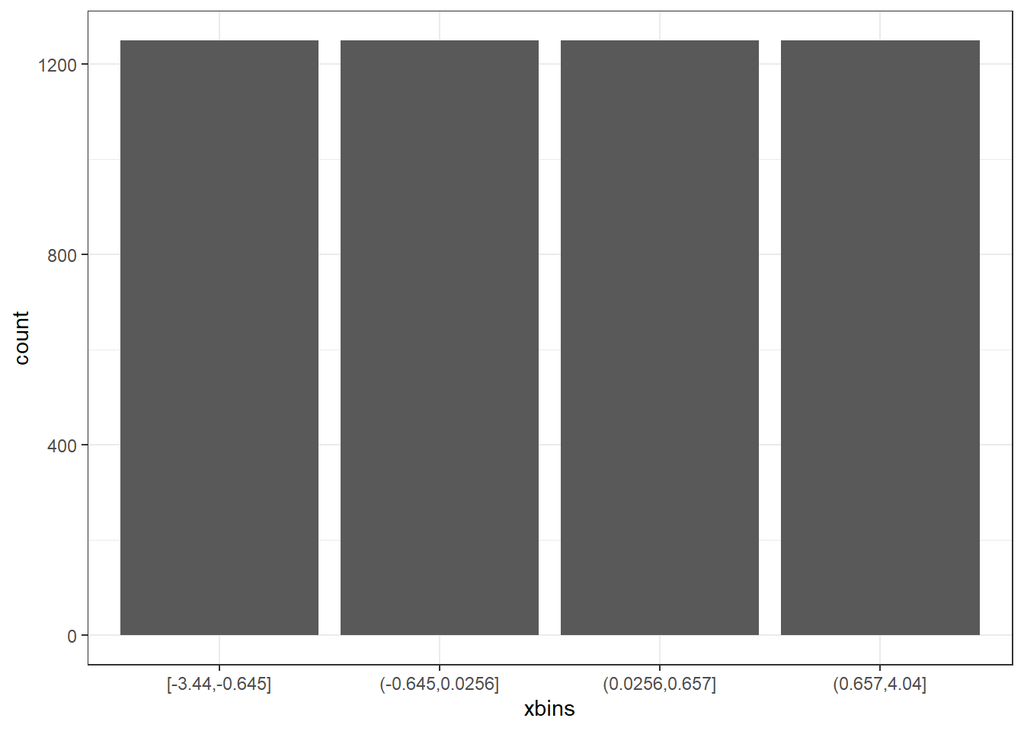

```r
xdf %>%
  mutate(xbins = cut(x, quantile(x), include.lowest = TRUE)) %>%
  ggplot(mapping = aes(x = xbins)) +
  geom_bar() +
  theme_bw()
```

Usually best to use **equal** or **uniform** bin sizes or bin intervals when visualizing histograms. Let’s use the `seq()` function to define evenly or uniform interval iszes in bins.

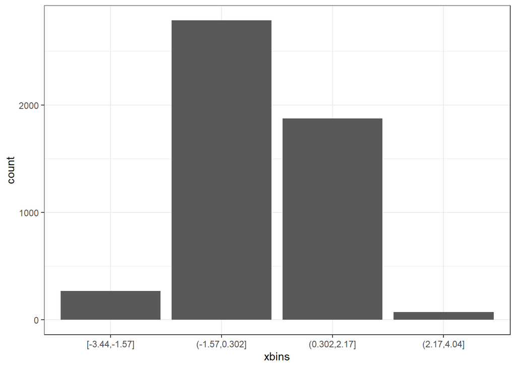

```r
xdf %>%
  mutate(xbins = cut(x,
                     seq(min(x), max(x), length.out = 5),
                     include.lowest = TRUE)) %>%
  ggplot(mapping = aes(x = xbins)) +
  geom_bar() +
  theme_bw()
```

Use more bins to get better “resolution” of the **distribution** of the variable.

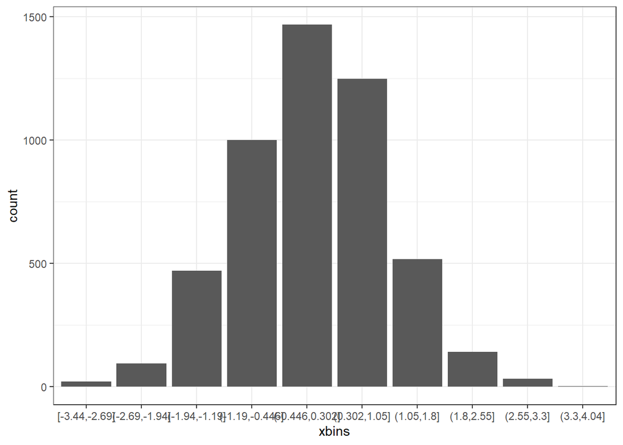

```r
xdf %>%
  mutate(xbins = cut(x,
                     seq(min(x), max(x), length.out = 11),
                     include.lowest = TRUE)) %>%
  ggplot(mapping = aes(x = xbins)) +
  geom_bar() +
  theme_bw()
```

Use even more bins to get further resolution, but we then have fewer observations in each bin.

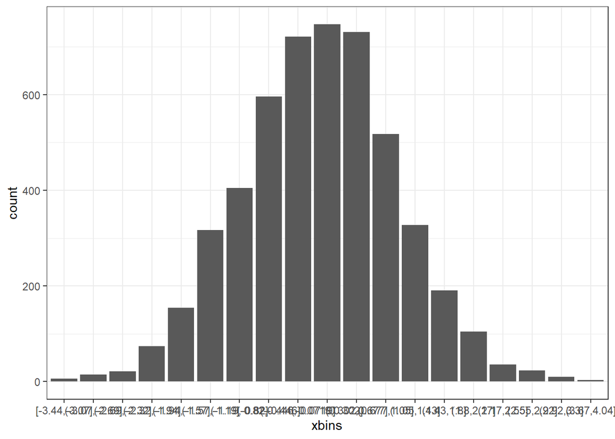

```r
xdf %>%
  mutate(xbins = cut(x,
                     seq(min(x), max(x), length.out = 21),
                     include.lowest = TRUE)) %>%
  ggplot(mapping = aes(x = xbins)) +
  geom_bar() +
  theme_bw()
```

We can just use the `geom_histogram()` geom to create the histogram.

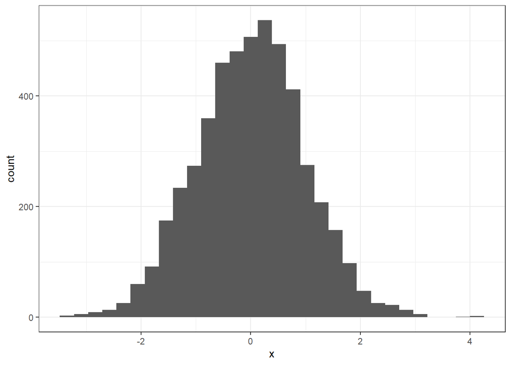

```r
xdf %>%
  ggplot(mapping = aes(x = x)) +
  geom_histogram() +
  theme_bw()
```

I tend to use 50 bins for thousands of observations.

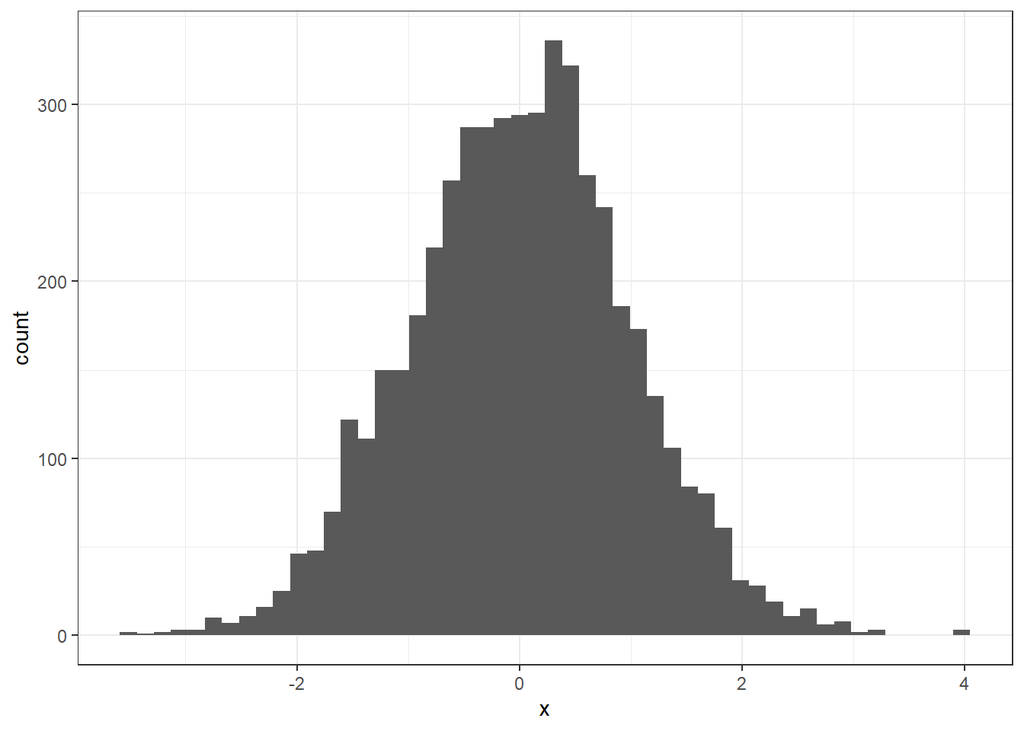

```r
xdf %>%
  ggplot(mapping = aes(x = x)) +
  geom_histogram(bins = 50) +
  theme_bw()
```

With a few hundred or less I’ll use 20 to 25.

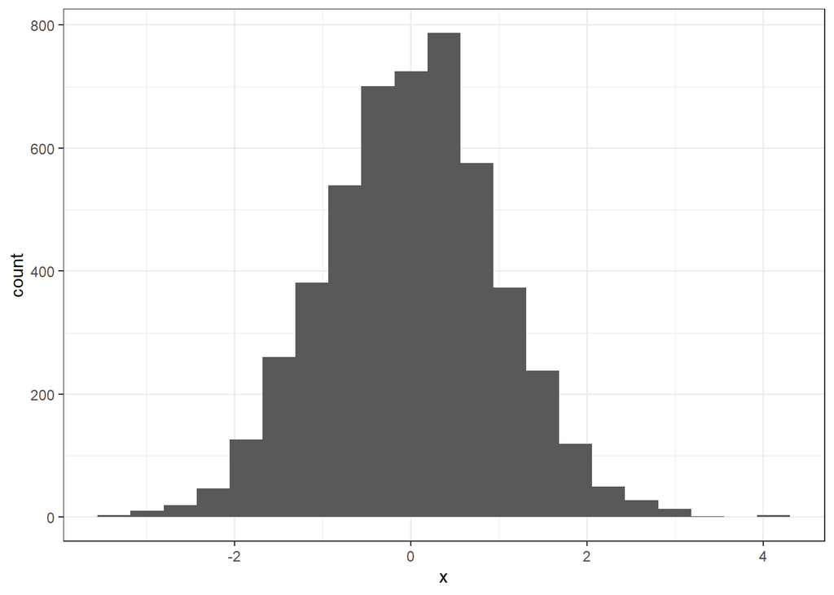

```r
xdf %>%
  ggplot(mapping = aes(x = x)) +
  geom_histogram(bins = 21) +
  theme_bw()
```

Let’s use 2000 bins.

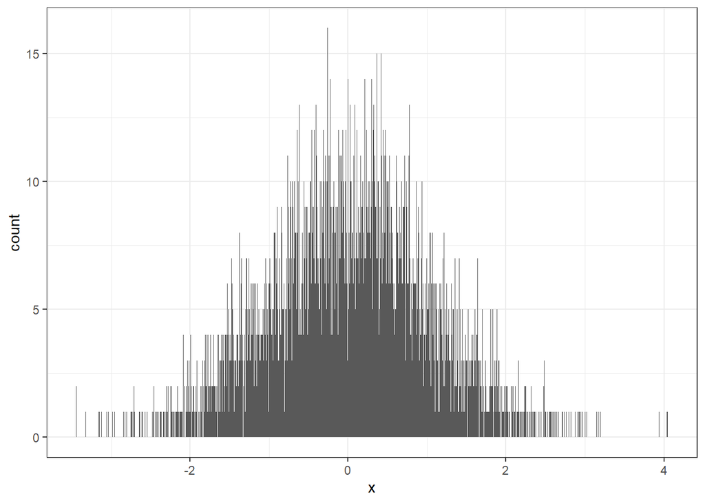

```r
xdf %>%
  ggplot(mapping = aes(x = x)) +
  geom_histogram(bins = 2000) +
  theme_bw()
```

A very small number of bins…might not help either.

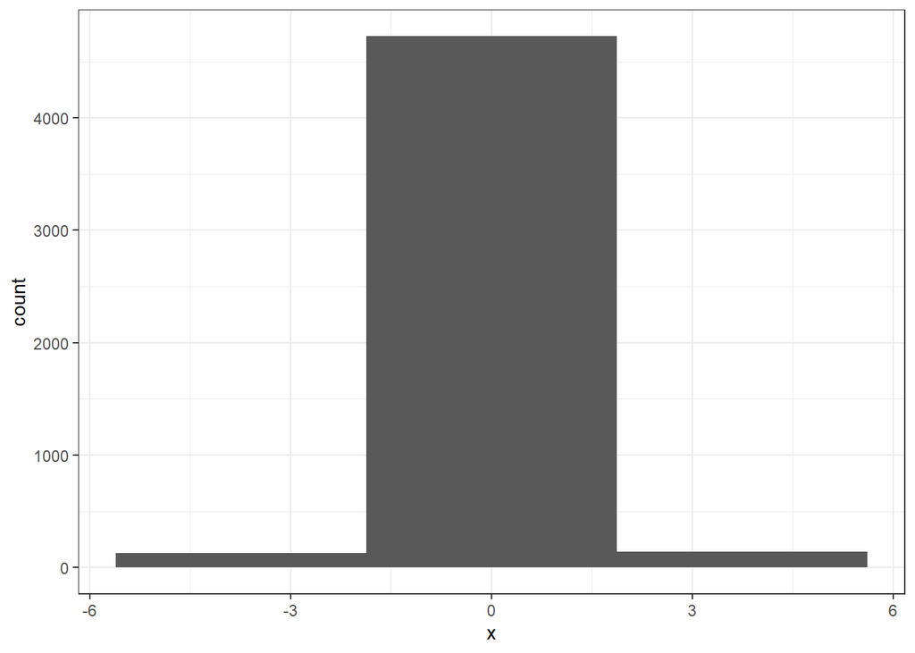

```r
xdf %>%
  ggplot(mapping = aes(x = x)) +
  geom_histogram(bins = 3) +
  theme_bw()
```

We can also decide the number of bins based on the **binwidth**

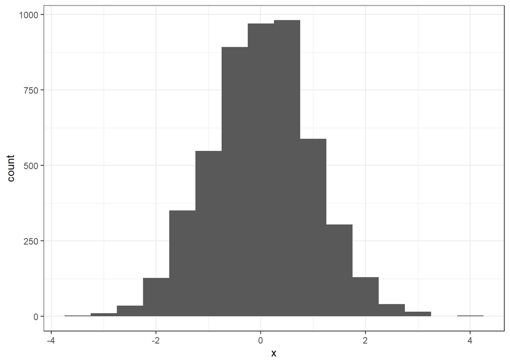

```r
xdf %>%
  ggplot(mapping = aes(x = x)) +
  geom_histogram(binwidth = 0.5) +
  theme_bw()
```

Use the `after_stat()` function to show the proportion per bin.

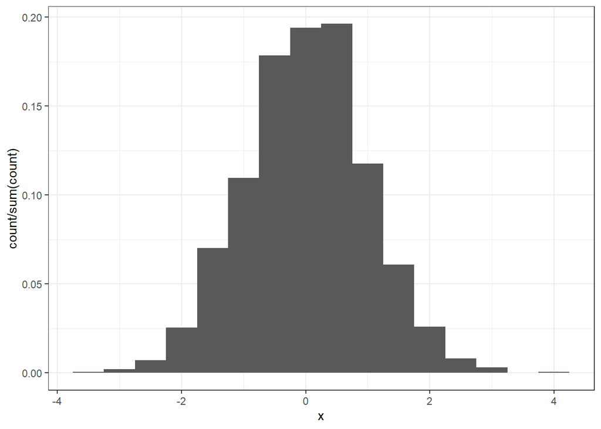

```r
xdf %>%
  ggplot(mapping = aes(x = x)) +
  geom_histogram(binwidth = 0.5,
                 mapping = aes(y = after_stat( count / sum(count) ))) +
  theme_bw()
```

Histogram is a representation of the **probability density function** (pdf). We can set the y-axis to the **density** of the bins. Density is calculated such that the integral or area under the curve equals 1.

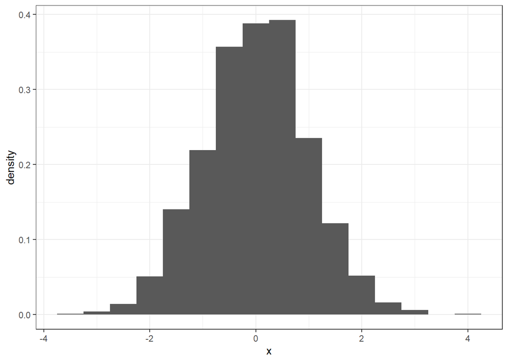

```r
xdf %>%
  ggplot(mapping = aes(x = x)) +
  geom_histogram(binwidth = 0.5,
                 mapping = aes(y = stat(density))) +
  theme_bw()
```

Instead, we could also represent the distribution with a **kernel density estimate**.

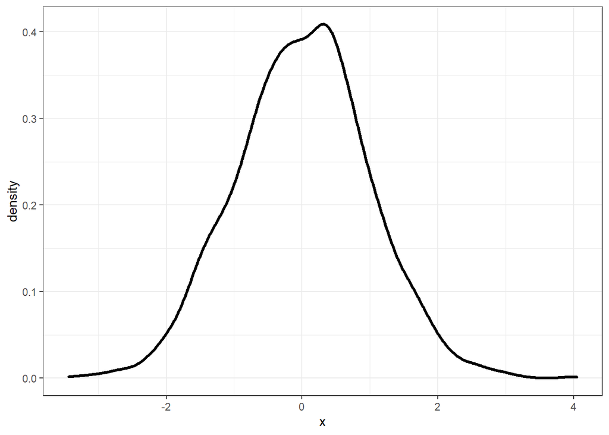

```r
xdf %>%
  ggplot(mapping = aes(x = x)) +
  geom_density(size = 1.1) +
  theme_bw()
```

The **bandwidth** controls how smooth the estimate is. We can control a multiplier to the estimated bandwidth.

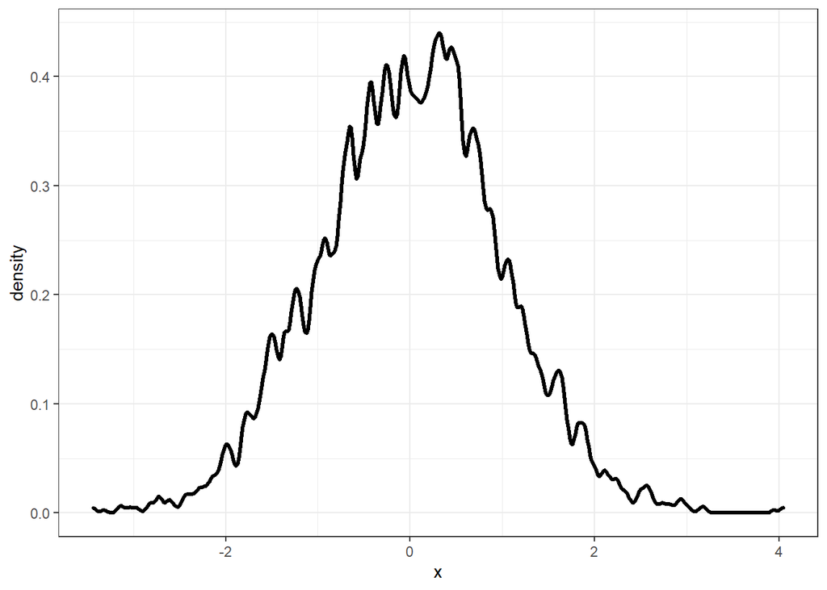

```r
xdf %>%
  ggplot(mapping = aes(x = x)) +
  geom_density(size = 1.1,
               adjust = 0.2) +
  theme_bw()
```

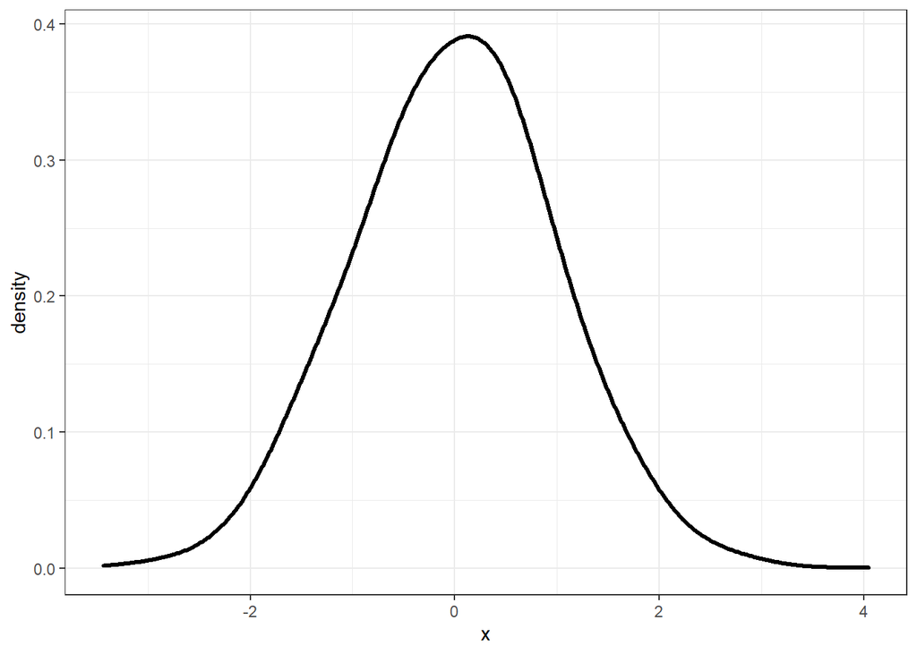

```r
xdf %>%
  ggplot(mapping = aes(x = x)) +
  geom_density(size = 1.1,
               adjust = 2) +
  theme_bw()
```

We can overlay the density with the histogram by adding two layers together.

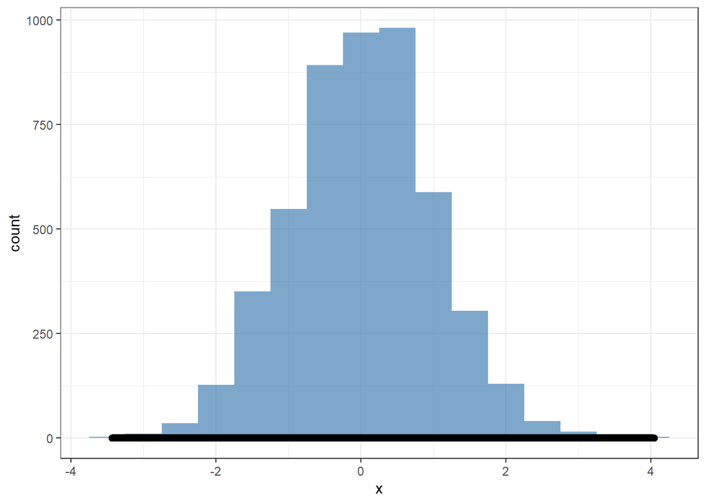

```r
xdf %>%
  ggplot(mapping = aes(x = x)) +
  geom_histogram(binwidth = 0.5, alpha = 0.7,
                 fill = 'steelblue') +
  geom_density(size = 2.5) +
  theme_bw()
```

To overlay the two the histogram must be instructed to plot the density.

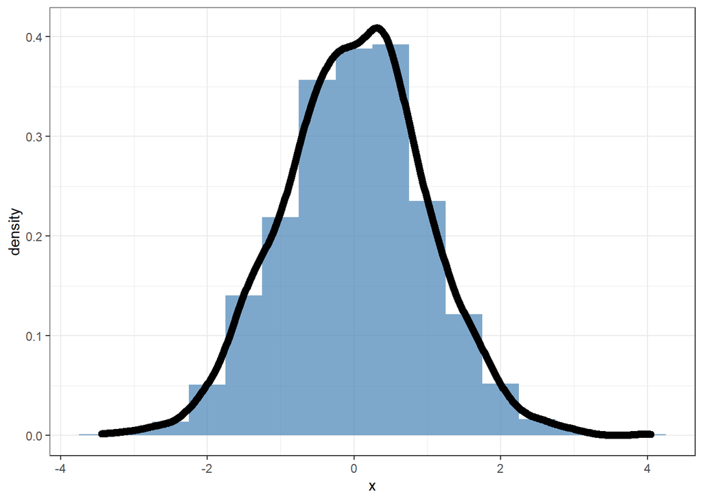

```r
xdf %>%
  ggplot(mapping = aes(x = x)) +
  geom_histogram(binwidth = 0.5, alpha = 0.7,
                 fill = 'steelblue',
                 mapping = aes(y = stat(density))) +
  geom_density(size = 2.5) +
  theme_bw()
```

Let’s go back to what happened with the `quantile()` defined bins. Let’s look at the quantile values on the histogram.

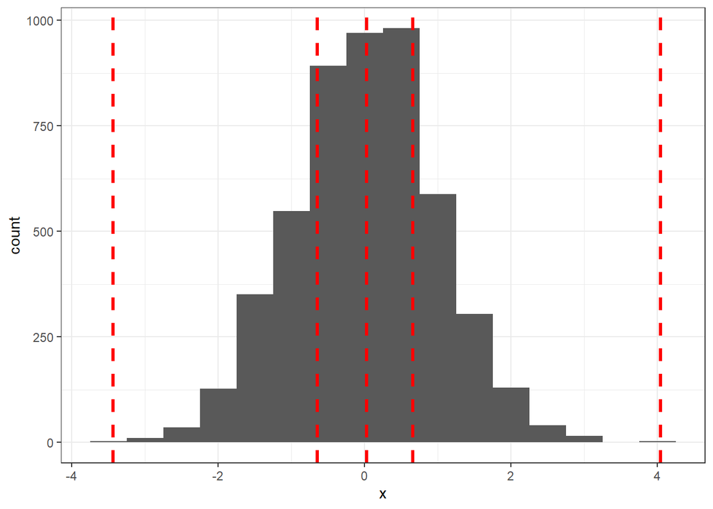

```r
xdf %>%
  ggplot(mapping = aes(x = x)) +
  geom_histogram(binwidth = 0.5) +
  geom_vline(xintercept = quantile(xdf$x),
             color = 'red', linetype = 'dashed', size = 1.15) +
  theme_bw()
```

Let’s look at the `quantile()` result.

```r
xdf %>% pull(x) %>% quantile()
```

```
##          0%         25%         50%         75%        100%
## -3.44004455 -0.64543627  0.02563519  0.65664619  4.04471889
```

The sister plot to the histogram or density is the CDF - the cumulative distribution function.

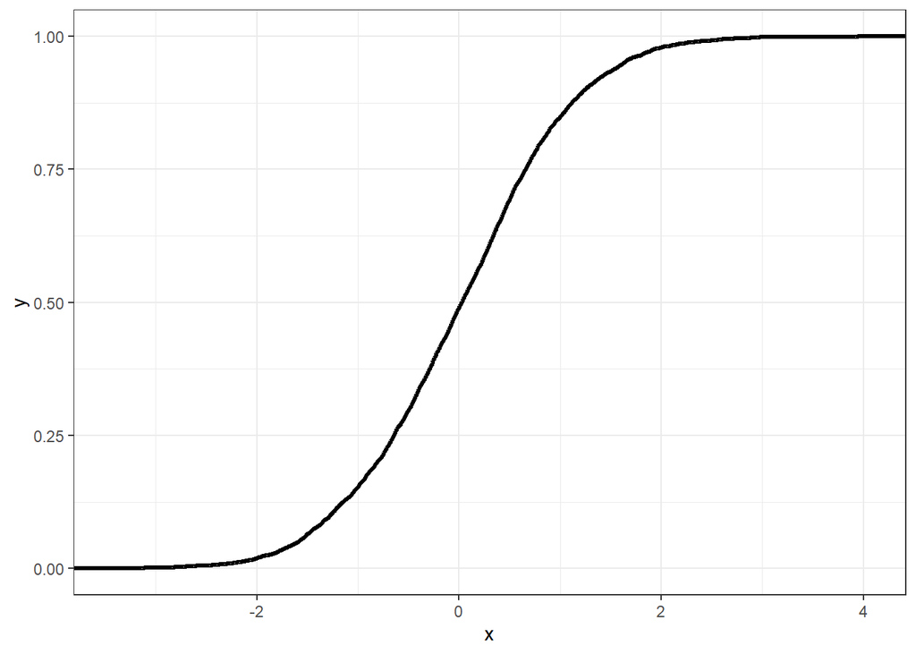

```r
xdf %>%
  ggplot(mapping = aes(x = x)) +
  stat_ecdf(size = 1.1) +
  theme_bw()
```

Let’s roughly calculate the CDF through our manual binning of the `x` values.

```r
xdf %>%
  mutate(xbins = cut(x,
                     breaks = seq(min(x), max(x), length.out = 11),
                     include.lowest = TRUE)) %>%
  count(xbins)
```

```
## # A tibble: 10 x 2
##    xbins              n
##    <fct>          <int>
##  1 [-3.44,-2.69]     21
##  2 (-2.69,-1.94]     95
##  3 (-1.94,-1.19]    471
##  4 (-1.19,-0.446]  1001
##  5 (-0.446,0.302]  1468
##  6 (0.302,1.05]    1249
##  7 (1.05,1.8]       518
##  8 (1.8,2.55]       141
##  9 (2.55,3.3]        33
## 10 (3.3,4.04]         3
```

Let’s use `geom_col()` to make this bar chart.

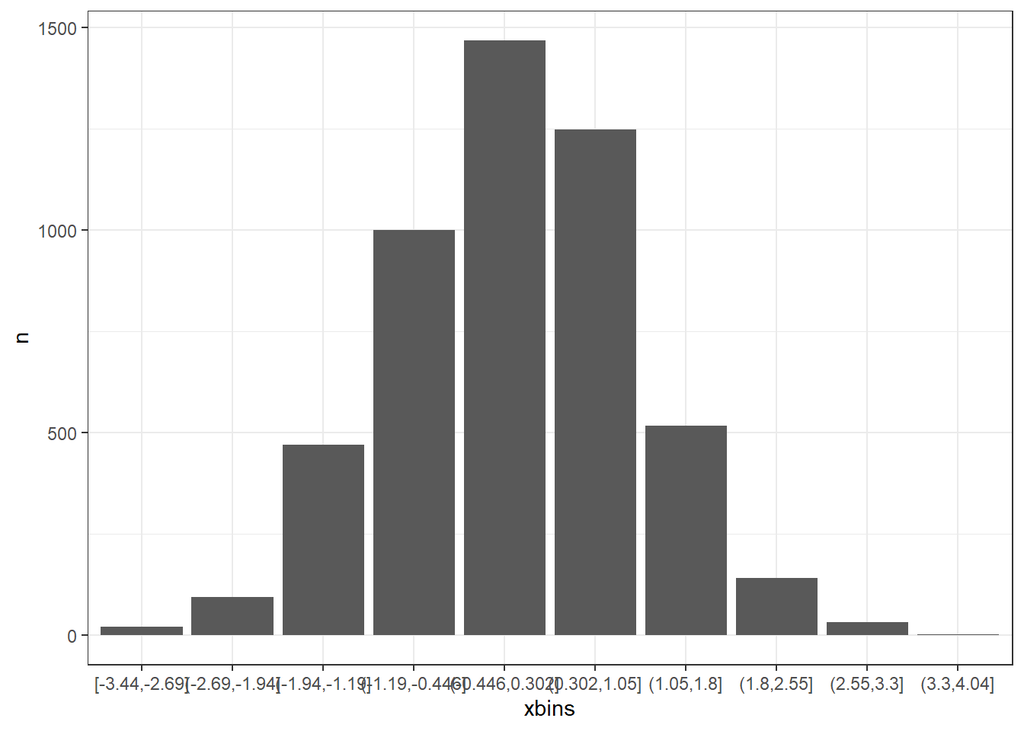

```r
xdf %>%
  mutate(xbins = cut(x,
                     breaks = seq(min(x), max(x), length.out = 11),
                     include.lowest = TRUE)) %>%
  count(xbins) %>%
  ggplot(mapping = aes(x = xbins, y = n)) +
  geom_col() +
  theme_bw()
```

Calculate the cumulative or rolling sum.

```r
xdf %>%
  mutate(xbins = cut(x,
                     breaks = seq(min(x), max(x), length.out = 11),
                     include.lowest = TRUE)) %>%
  count(xbins) %>%
  mutate(rolling_sum = cumsum(n))
```

```
## # A tibble: 10 x 3
##    xbins              n rolling_sum
##    <fct>          <int>       <int>
##  1 [-3.44,-2.69]     21          21
##  2 (-2.69,-1.94]     95         116
##  3 (-1.94,-1.19]    471         587
##  4 (-1.19,-0.446]  1001        1588
##  5 (-0.446,0.302]  1468        3056
##  6 (0.302,1.05]    1249        4305
##  7 (1.05,1.8]       518        4823
##  8 (1.8,2.55]       141        4964
##  9 (2.55,3.3]        33        4997
## 10 (3.3,4.04]         3        5000
```

Visualize our cumulative sum.

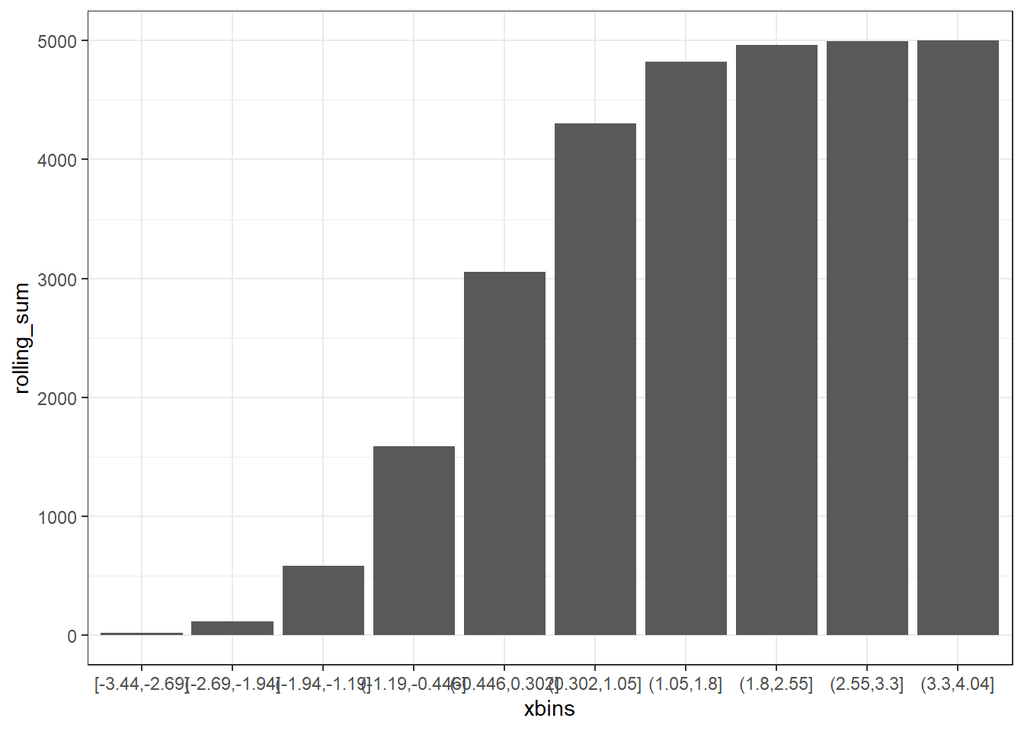

```r
xdf %>%
  mutate(xbins = cut(x,
                     breaks = seq(min(x), max(x), length.out = 11),
                     include.lowest = TRUE)) %>%
  count(xbins) %>%
  mutate(rolling_sum = cumsum(n)) %>%
  ggplot(mapping = aes(x = xbins, y = rolling_sum)) +
  geom_col() +
  theme_bw()
```

We want the rolling or cumulative proportion.

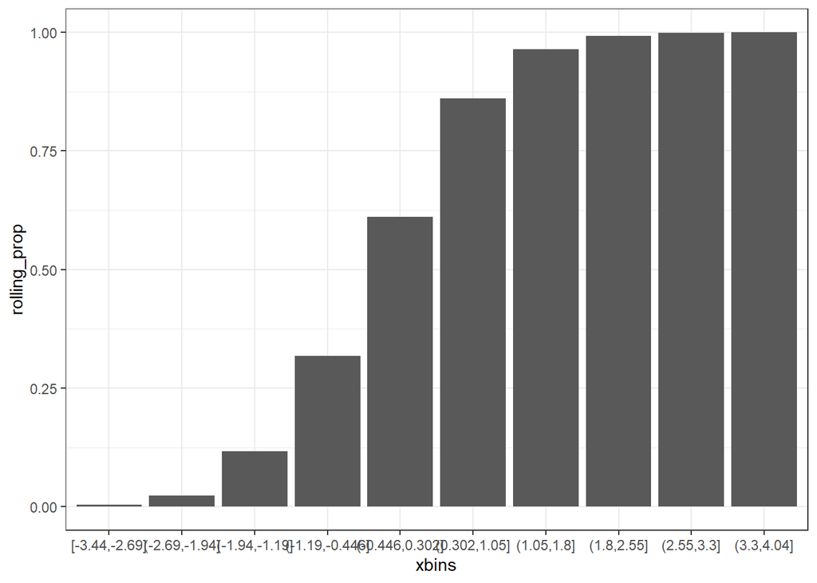

```r
xdf %>%
  mutate(xbins = cut(x,
                     breaks = seq(min(x), max(x), length.out = 11),
                     include.lowest = TRUE)) %>%
  count(xbins) %>%
  mutate(rolling_sum = cumsum(n)) %>%
  mutate(rolling_prop = rolling_sum / sum(n)) %>%
  ggplot(mapping = aes(x = xbins, y = rolling_prop)) +
  geom_col() +
  theme_bw()
```

Let’s see what happens if we have fewer observations.

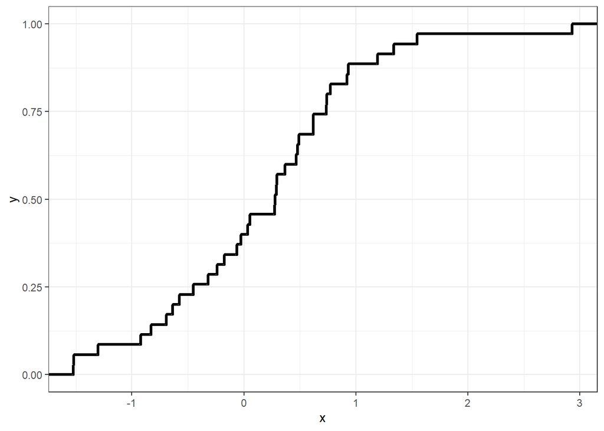

```r
xdf %>%
  slice(1:35) %>%
  ggplot(mapping = aes(x = x)) +
  stat_ecdf(size = 1.1) +
  theme_bw()
```

Make the small data set.

```r
xsmall <- xdf %>%
  slice(1:35)
```

Look at the CDF for the small data set with specific quantiles called out.

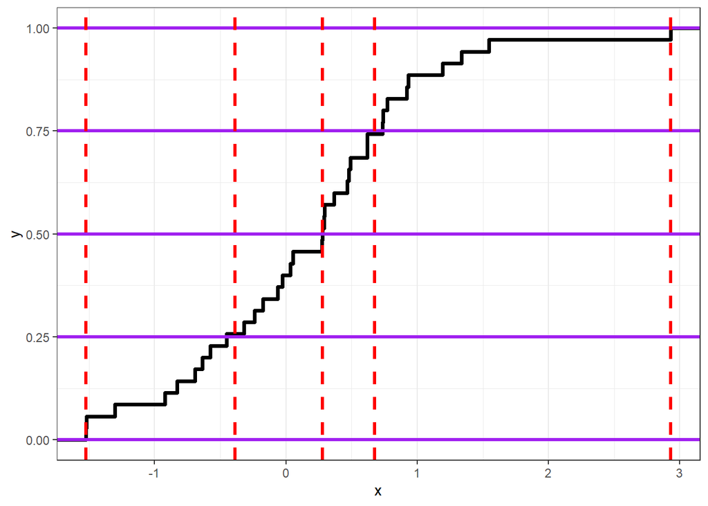

```r
xsmall %>%
  ggplot(mapping = aes(x = x)) +
  stat_ecdf(size = 1.25) +
  geom_hline(yintercept = c(0, 0.25, 0.5, 0.75, 1),
             color = 'purple', size = 1.1) +
  geom_vline(xintercept = quantile(xsmall$x),
             color = 'red', linetype = 'dashed', size = 1.2) +
  theme_bw()
```